# Problem Set 3

Due 9/14 by the start of class.

## R practice: World Development Indicators

This week, you’ll use a small subset of variables from the World Bank’s Open Data platform [data.worldbank.org](https://data.worldbank.org/) obtained using the [WDI package](https://www.r-project.org/nosvn/pandoc/WDI.html). Start by downloading the ps3.zip file. The folder contains the R script I used to create the data frame (ps3_prep.R), the resulting data file (wdi_clean.csv), and the bones of an R markdown file. You don’t need to re-run the ps3_prep.R file, I just wanted you to have a record of how it was generated.

This week’s work should be submitted as an R markdown file (though you are free to use a regular ol’ R script to work out your code before adding it to the markdown file if you like – that’s what I would do), called lastname_ps3.Rmd. This file should be knittable by me assuming it is placed in my copy of the week3_materials folder in the same places as the initial_ps3.Rmd file.

Complete the tasks as described in the file and save (and knit). You’ll submit the completed Rmd file to me on slack (via direct message) – just the .Rmd file.

## Your Data

Last week you began validating and cleaning at least two key variables to work with for the final project and began visualizing their distributions. This week, add

1. A cleaning script that contains any code for data cleaning, preparation, derivation, and wrangling that you’ve written so far and saves a “cleaned” version of your data. If there’s wrangling you’d like to do but are struggling with, make a comment in this script and I’ll have a look.
2. An R markdown script that reads in the cleaned data, begins to add exposition to the work (explaining the questions, the variables, etc.), and generates at least one visual beyond the univariate distributions you submitted last week. If there is something you’re hoping to do this visual – either something you haven’t made work yet or something we haven’t talked about yet – add an explanation in the prose and I’ll have a look.

Send me both the cleaning script and the R markdown files via slack (if I you haven’t sent a file with the data you are currently using, send that via slack as well).

## Good Data Visualizations

Thinking about Cairo’s criteria for good data visualization (truthful, functional, beautiful, insightful, enlightening) and/or the converse of Schwabish’s guidelines (showing data, reducing clutter, avoiding spaghetti, integrating text), **find a data visualization you think is especially “good”** and post it to the slack channel “goodviz-badviz” with a brief explanation of what you think it does well (this is a chance to learn from one another). The Visualization Inspiration links on the resource page might help.

[xkcd](https://xkcd.com/798/) inspiration

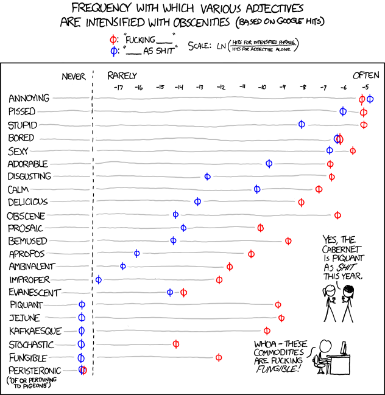